#### Initial hypothesis: here I have chosen three explanatory variables to predict GNI per capita

- **Life expectancy at birth (life.exp)** means the long and healthy life citizens can expect, good health is an important factor to wealth, so we can use life.exp to predict GNI.
- **Gender equal particiaption in labour force (ratiolab.fm)** can be use to predict GNI.
- **Expected years of schooling (exp.y.edu)**, more years of education, more knowledge to boost the country’s economy, so is also a good indicator for GNI preidiction.

## Data wrangling:

#### you can see the processed data wrangling in my github: https://github.com/tzsu/IODS-project/blob/master/data/create_human.R

#### Original data source: UN DEvelopment Programme - Human Development Reports from http://hdr.undp.org/en/content/human-development-index-hdi

### 1. About the Human data:

*The Human data includes two data sets: “Human development” and “Gender inequality”. We keep only the countries in both data sets, and exclude rows with missing values. GNI is transform to numeric, and two ratios concerning gender education and labour participation is presented here. Now the **Human** data we will use for performing analysis has 155 observations and the folowing 8 variables:*

#### the 8 variables:

- ratioedu2.fm = Share of female population with secondary education over(/) share of male population with secondary education
- ratiolab.fm = Share of female population that participates in labour force over(/) share of male population that participates in labour force
- exp.y.edu = Expected years of schooling
- life.exp = Life expectancy at birth
- gni.cap = Gross national income per capita
- mmr = Maternal mortality ratio
- ad.b.r = Adolescent birth rate
- par% = population with at least some secondary education

#### Take a glimpse at the data set

```r
#A glimpse at the human data set
glimpse(human)
```

```
## Observations: 155
## Variables: 8
## $ ratioedu2.fm <dbl> 1.0072389, 0.9968288, 0.9834369, 0.9886128, 0.969...
## $ ratiolab.fm  <dbl> 0.8908297, 0.8189415, 0.8251001, 0.8840361, 0.828...
## $ exp.y.edu    <dbl> 17.5, 20.2, 15.8, 18.7, 17.9, 16.5, 18.6, 16.5, 1...
## $ life.exp     <dbl> 81.6, 82.4, 83.0, 80.2, 81.6, 80.9, 80.9, 79.1, 8...
## $ gni.cap      <int> 64992, 42261, 56431, 44025, 45435, 43919, 39568, ...
## $ mmr          <int> 4, 6, 6, 5, 6, 7, 9, 28, 11, 8, 6, 4, 8, 4, 27, 2...
## $ ad.b.r       <dbl> 7.8, 12.1, 1.9, 5.1, 6.2, 3.8, 8.2, 31.0, 14.5, 2...
## $ par.         <dbl> 39.6, 30.5, 28.5, 38.0, 36.9, 36.9, 19.9, 19.4, 2...
```

```r
#Summary of the variables
summary(human)
```

```
##   ratioedu2.fm     ratiolab.fm       exp.y.edu        life.exp
##  Min.   :0.1717   Min.   :0.1857   Min.   : 5.40   Min.   :49.00
##  1st Qu.:0.7264   1st Qu.:0.5984   1st Qu.:11.25   1st Qu.:66.30
##  Median :0.9375   Median :0.7535   Median :13.50   Median :74.20
##  Mean   :0.8529   Mean   :0.7074   Mean   :13.18   Mean   :71.65
##  3rd Qu.:0.9968   3rd Qu.:0.8535   3rd Qu.:15.20   3rd Qu.:77.25
##  Max.   :1.4967   Max.   :1.0380   Max.   :20.20   Max.   :83.50
##     gni.cap            mmr             ad.b.r            par.
##  Min.   :   581   Min.   :   1.0   Min.   :  0.60   Min.   : 0.00
##  1st Qu.:  4198   1st Qu.:  11.5   1st Qu.: 12.65   1st Qu.:12.40
##  Median : 12040   Median :  49.0   Median : 33.60   Median :19.30
##  Mean   : 17628   Mean   : 149.1   Mean   : 47.16   Mean   :20.91
##  3rd Qu.: 24512   3rd Qu.: 190.0   3rd Qu.: 71.95   3rd Qu.:27.95
##  Max.   :123124   Max.   :1100.0   Max.   :204.80   Max.   :57.50
```

### 2. Graphical overview of the data

#### The correlation figure can show the correlation more easily than the scatter plot matrix.

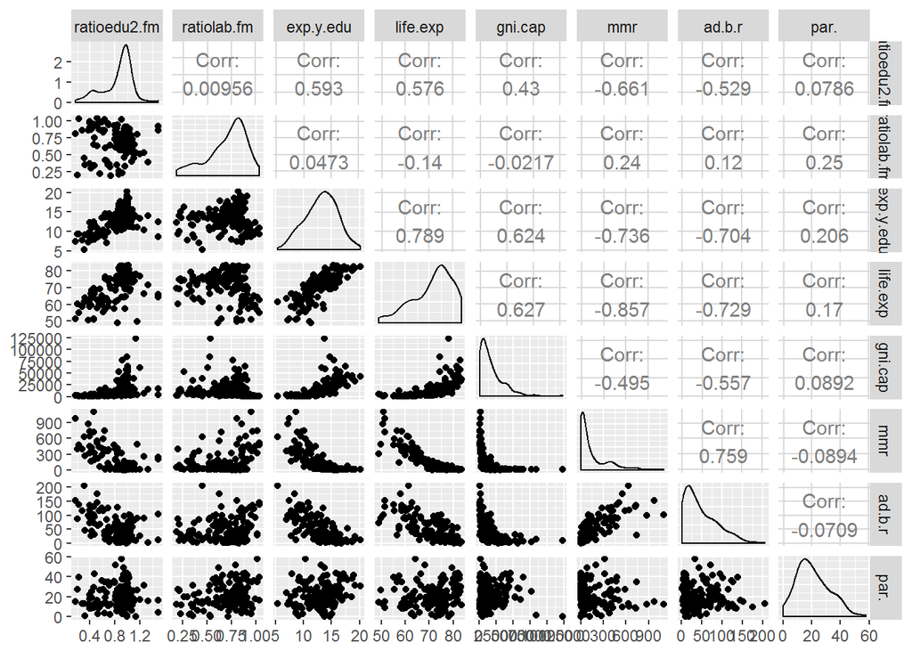

```r
#pair up all 8 variables to see if there is any relationship
ggpairs(human)
```

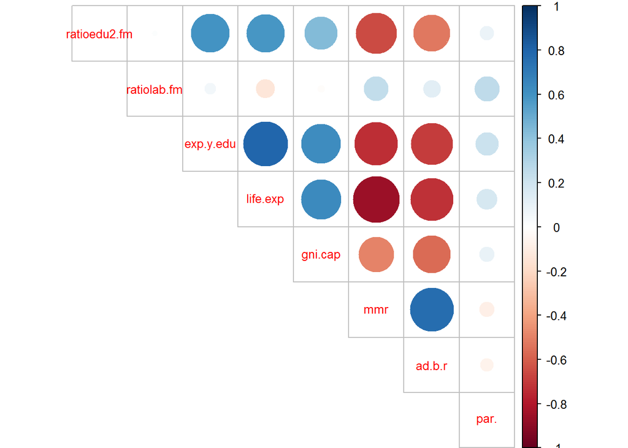

```r
corrplot(round(cor(human), digits = 2), method = "circle", type = "upper", tl.pos = "d", tl.cex = 0.8)
```

#### From the correlation figure, ratiolab.fm seems to have no relationship with gni.cap, but let’s fit a multiple regression model to the data and see.

### 3. Fitting of the regression model

#### The target variable is GNI per capita, and the three explanatory variables are:

- life.exp = Life expectancy at birth
- ratiolab.fm = Share of female population that participates in labour force over(/) share of male population that participates in labour force
- exp.y.edu = Expected years of schooling

```r
# create a regression model
my_r_model <- lm(gni.cap ~ life.exp + ratiolab.fm + exp.y.edu ,  data = human)
# print out a summary of the model
summary(my_r_model)
```

```
##
## Call:
## lm(formula = gni.cap ~ life.exp + ratiolab.fm + exp.y.edu, data = human)
##
## Residuals:
##    Min     1Q Median     3Q    Max
## -17827  -8349  -2526   4073  99065
##
## Coefficients:
##             Estimate Std. Error t value Pr(>|t|)
## (Intercept) -69935.4    12517.2  -5.587 1.05e-07 ***
## life.exp       803.7      231.2   3.476 0.000664 ***
## ratiolab.fm   1193.3     5955.0   0.200 0.841451
## exp.y.edu     2211.2      672.3   3.289 0.001251 **
## ---
## Signif. codes:  0 '***' 0.001 '**' 0.01 '*' 0.05 '.' 0.1 ' ' 1
##
## Residual standard error: 14050 on 151 degrees of freedom
## Multiple R-squared:  0.4375, Adjusted R-squared:  0.4263
## F-statistic: 39.14 on 3 and 151 DF,  p-value: < 2.2e-16
```

#### The above summary shows that the multiple regression equation to be approximately:

**gni.cap = -69935 + (life.exp x 803) + (ratiolab.fm x 1193) + (exp.y.edu x 2211)**

- if the value *life.exp* increase by one, *gni.cap* will increase by 803 (if other variables stay the same), and so on. When all three explanatory variables are 0, *gni.cap* is predicted to be -69935.(Which in real life will not happen. )
- From F test for overall significance, we can conclude that at least one explanatory variable affects *gni.cap*.
- The t test shows evidence of *life.exp* affecting predictions for *gni.cap*, however, it is also quite clear that *ratiolab.fm* has no linear relationship with our target variables. Thus it will make more sense to eliminate the least probability value, ratiolab.fm to get a more accurate equation for prediction.

### 4. Multiple regression model - remove ratiolab.fm from the previous model

#### Now refit the regression model with just two variables:

```r
# recreate a regression model
my_r_model <- lm(gni.cap ~ life.exp + exp.y.edu ,  data = human)
# print out a summary of the model
summary(my_r_model)
```

```
##
## Call:
## lm(formula = gni.cap ~ life.exp + exp.y.edu, data = human)
##
## Residuals:
##    Min     1Q Median     3Q    Max
## -17850  -8667  -2510   3986  98921
##
## Coefficients:
##             Estimate Std. Error t value Pr(>|t|)
## (Intercept) -68592.0    10536.9  -6.510 1.03e-09 ***
## life.exp       790.2      220.6   3.582 0.000458 ***
## exp.y.edu     2246.2      647.2   3.471 0.000676 ***
## ---
## Signif. codes:  0 '***' 0.001 '**' 0.01 '*' 0.05 '.' 0.1 ' ' 1
##
## Residual standard error: 14000 on 152 degrees of freedom
## Multiple R-squared:  0.4373, Adjusted R-squared:  0.4299
## F-statistic: 59.06 on 2 and 152 DF,  p-value: < 2.2e-16
```

#### The new summary shows that the regression equation at about

#### **gni.cap = -68592 + (life.exp x 790) + (exp.y.edu x 2246)**

- Both the explanatory variables have positive affects on the target variable.
- Multiple R-squared here indicates that 43.7% of the variation in gni.cap is explained by the variation in life.exp and exp.y.edu. This means the model is not very good since there is still about 56% of the relationship between the explanatory and the dependent variable remains unexplained. ####Conclusion: *my initail hypothesis is not supported by this analysis. The use of life expectancy at birth and expected year of study to predict gross national income per capita is not very reliable.*

### 5. Model validation

#### The linear regression model assumes the following 4 points:

- Errors are normally distributed.
- Errors are not correlated.
- Errors have constant variance.
- The size of a given error does not depend on the explanatory variables

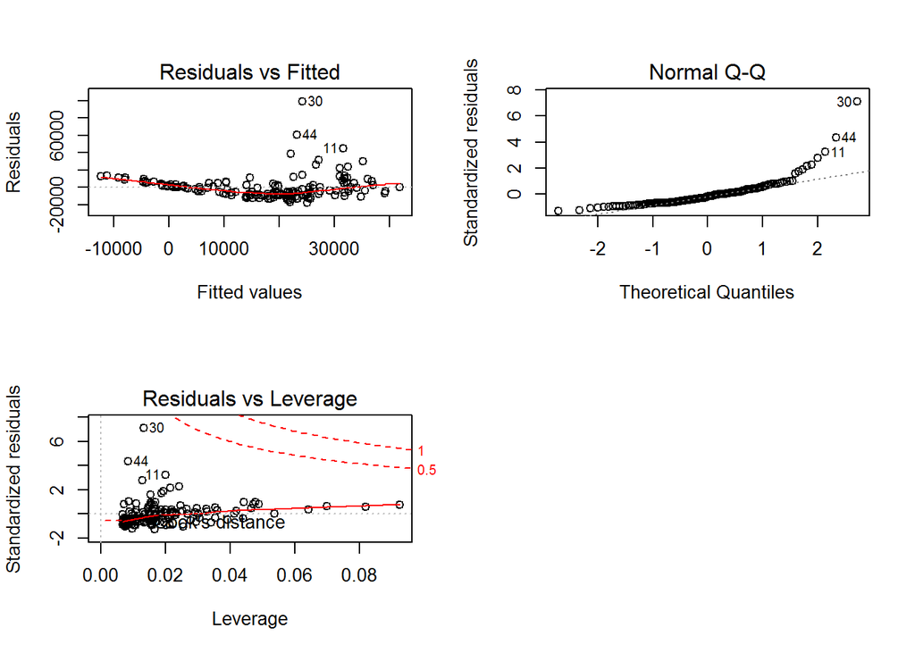